# B2 assignment - multivariate analysis - group 16

Anastasia Manjavidze

Luic Damian

15/03/2023

# 1 Data exploration

## 1.1 Basic statistics and information

### 1.1.1 Dimensions

```r
dim(data)
```

```
## [1] 30 25
```

The data set has 30 objects and 25 variables

### 1.1.2 Structure

```r
str(data)
```

```
## 'data.frame':    30 obs. of  25 variables:
##  $ spp1 : int  35 37 43 31 49 45 39 32 42 33 ...
##  $ spp2 : int  12 7 9 14 10 6 8 6 14 9 ...
##  $ spp3 : int  31 24 26 29 24 29 26 44 24 33 ...
##  $ spp4 : int  34 48 42 26 32 45 34 35 30 39 ...
##  $ spp5 : int  42 35 36 22 36 39 31 26 29 34 ...
##  $ spp6 : int  46 62 53 44 55 59 45 47 41 57 ...
##  $ spp7 : int  11 15 16 18 21 10 13 10 16 13 ...
##  $ spp8 : int  33 44 31 38 37 34 35 45 38 39 ...
##  $ spp9 : int  33 22 28 37 31 26 23 33 31 33 ...
##  $ spp10: int  41 33 27 31 42 30 28 35 36 34 ...
##  $ spp11: int  36 21 22 32 33 22 23 31 31 36 ...
##  $ spp12: int  30 38 29 34 39 41 35 41 40 35 ...
##  $ spp13: int  16 11 9 11 7 12 24 15 12 14 ...
##  $ spp14: int  27 15 21 33 15 17 19 18 18 26 ...
##  $ spp15: int  31 23 22 24 33 29 28 31 24 36 ...
##  $ spp16: int  32 26 42 26 34 32 33 33 31 31 ...
##  $ spp17: int  32 36 30 31 27 34 35 37 20 20 ...
##  $ spp18: int  37 33 36 35 40 42 35 37 34 38 ...
##  $ spp19: int  15 12 14 10 15 16 12 13 15 7 ...
##  $ spp20: int  21 22 23 28 15 20 30 27 27 16 ...
##  $ env1 : num  64.6 52.1 54.5 38.7 51.7 ...
##  $ env2 : num  66.5 75.7 50.3 82.4 59.7 ...
##  $ env3 : num  154 150 179 150 162 ...
##  $ env4 : num  132 141 119 149 130 ...
##  $ env5 : num  181 159 163 161 165 ...
```

Species abundance data consists of integers, environmental variables are numeric, i.e. continuous

### 1.1.3 Summary

```r
summary(data)
```

```
##       spp1            spp2            spp3            spp4
##  Min.   :27.00   Min.   : 5.00   Min.   :24.00   Min.   :22.00
##  1st Qu.:32.25   1st Qu.: 7.25   1st Qu.:26.00   1st Qu.:32.25
##  Median :36.50   Median : 9.50   Median :28.50   Median :34.50
##  Mean   :37.10   Mean   : 9.90   Mean   :30.03   Mean   :35.00
##  3rd Qu.:42.00   3rd Qu.:12.00   3rd Qu.:34.00   3rd Qu.:38.50
##  Max.   :49.00   Max.   :17.00   Max.   :44.00   Max.   :48.00
##       spp5            spp6            spp7            spp8            spp9
##  Min.   :22.00   Min.   :41.00   Min.   :10.00   Min.   :27.00   Min.   :22
##  1st Qu.:29.00   1st Qu.:46.00   1st Qu.:11.25   1st Qu.:32.25   1st Qu.:26
##  Median :31.50   Median :53.00   Median :15.00   Median :36.00   Median :30
##  Mean   :32.03   Mean   :52.07   Mean   :14.97   Mean   :37.03   Mean   :30
##  3rd Qu.:36.00   3rd Qu.:57.75   3rd Qu.:17.75   3rd Qu.:39.75   3rd Qu.:33
##  Max.   :42.00   Max.   :65.00   Max.   :23.00   Max.   :52.00   Max.   :40
##      spp10           spp11           spp12           spp13           spp14
##  Min.   :22.00   Min.   :21.00   Min.   :25.00   Min.   : 7.00   Min.   :13.0
##  1st Qu.:29.25   1st Qu.:25.25   1st Qu.:33.00   1st Qu.: 9.25   1st Qu.:18.0
##  Median :32.00   Median :31.00   Median :35.50   Median :12.00   Median :22.5
##  Mean   :33.03   Mean   :29.97   Mean   :36.93   Mean   :12.00   Mean   :22.0
##  3rd Qu.:36.75   3rd Qu.:33.00   3rd Qu.:41.00   3rd Qu.:14.00   3rd Qu.:25.0
##  Max.   :45.00   Max.   :42.00   Max.   :51.00   Max.   :24.00   Max.   :33.0
##      spp15           spp16           spp17           spp18
##  Min.   :22.00   Min.   :22.00   Min.   :19.00   Min.   :26.00
##  1st Qu.:26.25   1st Qu.:29.50   1st Qu.:27.00   1st Qu.:33.25
##  Median :29.50   Median :33.00   Median :30.50   Median :37.00
##  Mean   :30.00   Mean   :32.93   Mean   :29.90   Mean   :37.00
##  3rd Qu.:33.75   3rd Qu.:36.00   3rd Qu.:33.75   3rd Qu.:40.75
##  Max.   :43.00   Max.   :48.00   Max.   :39.00   Max.   :51.00
##      spp19           spp20            env1            env2
##  Min.   : 5.00   Min.   :15.00   Min.   :35.35   Min.   :50.28
##  1st Qu.: 9.25   1st Qu.:18.00   1st Qu.:43.18   1st Qu.:60.22
##  Median :13.00   Median :21.00   Median :51.29   Median :66.44
##  Mean   :12.03   Mean   :22.00   Mean   :50.27   Mean   :68.84
##  3rd Qu.:15.00   3rd Qu.:26.75   3rd Qu.:55.10   3rd Qu.:77.69
##  Max.   :18.00   Max.   :32.00   Max.   :68.90   Max.   :90.06
##       env3            env4            env5
##  Min.   :119.1   Min.   :113.7   Min.   :140.3
##  1st Qu.:148.8   1st Qu.:128.1   1st Qu.:161.0
##  Median :156.3   Median :138.5   Median :168.5
##  Mean   :158.5   Mean   :136.4   Mean   :168.5
##  3rd Qu.:174.1   3rd Qu.:142.9   3rd Qu.:177.3
##  Max.   :184.9   Max.   :160.8   Max.   :184.8
```

The summary shows the minumum, 1st quartile, median, mean, 3rd quartile and max values of each variable

## 1.2 Distribution and correlation of predictors

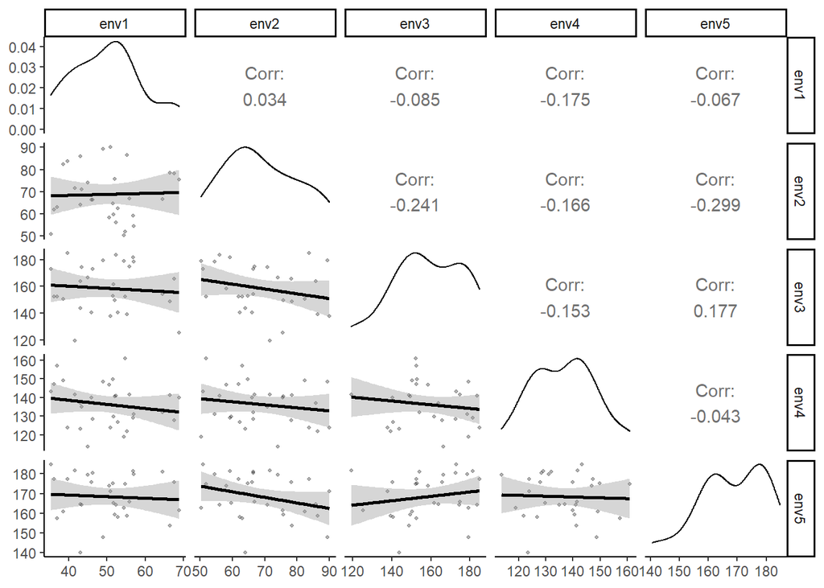

```r
do_env = ggpairs(data, columns = c(21:25), lower = list(continuous = wrap("smooth", alpha = 0.3, size = 0.7)))+
  theme_classic()
do_env
```

All environmental variables are more or less normally distributed and slightly correlated to each other. It should be checked whether multicollinearity is present or not.

## 1.3 Collinearity

Checking for collinearity with variance inflation parameter (VIF)

```r
vif(lm(spp1 ~ env1 + env2 + env3 + env4 + env5, data = data))
```

```
##     env1     env2     env3     env4     env5
## 1.051096 1.207088 1.130897 1.122332 1.124196
```

All VIF for predictors are far below 5, hence there is no problematic collinearity

## 1.4 Linearity between predictors (environmental variables) and dependent variables (species)

**Because of readablility only 5 species and the 5 environmental parameters are plotted in one graph**

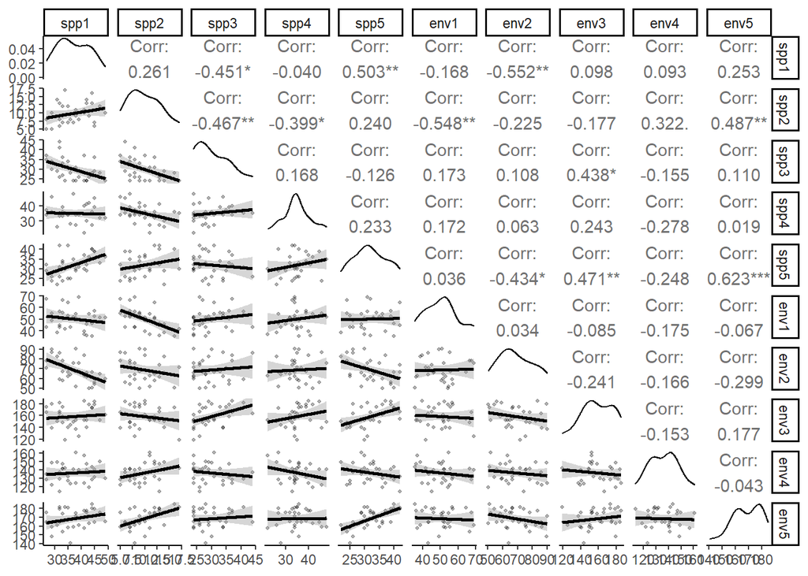

```r
do_sp1_sp5_env = ggpairs(data, columns = c(1:5,21:25), lower = list(continuous = wrap("smooth", alpha = 0.3, size = 0.7)))+
  theme_classic()
do_sp1_sp5_env
```

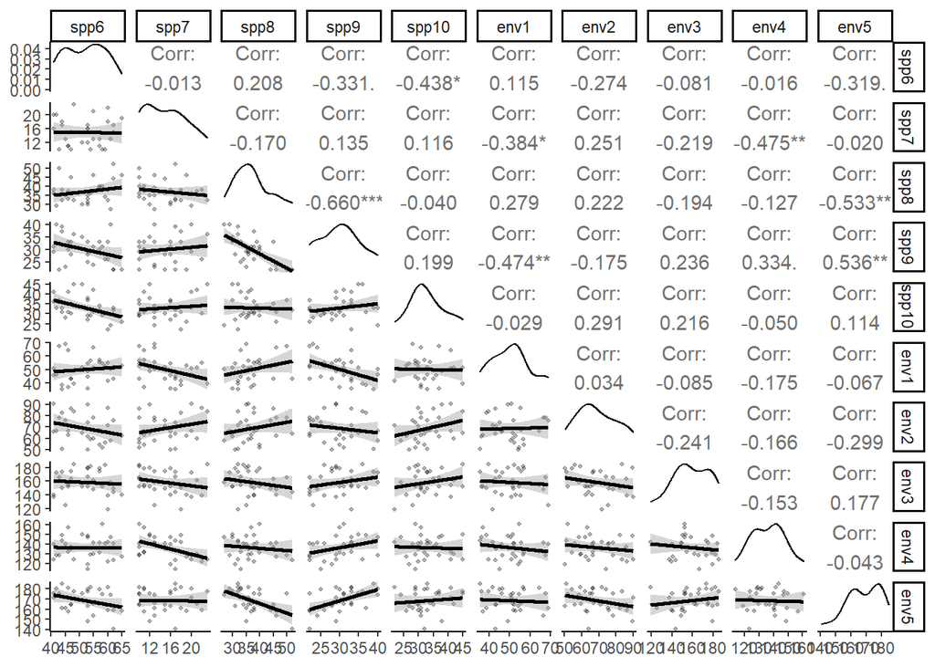

```r
do_sp6_sp10_env = ggpairs(data, columns = c(6:10,21:25), lower = list(continuous = wrap("smooth", alpha = 0.3, size = 0.7)))+
  theme_classic()
do_sp6_sp10_env
```

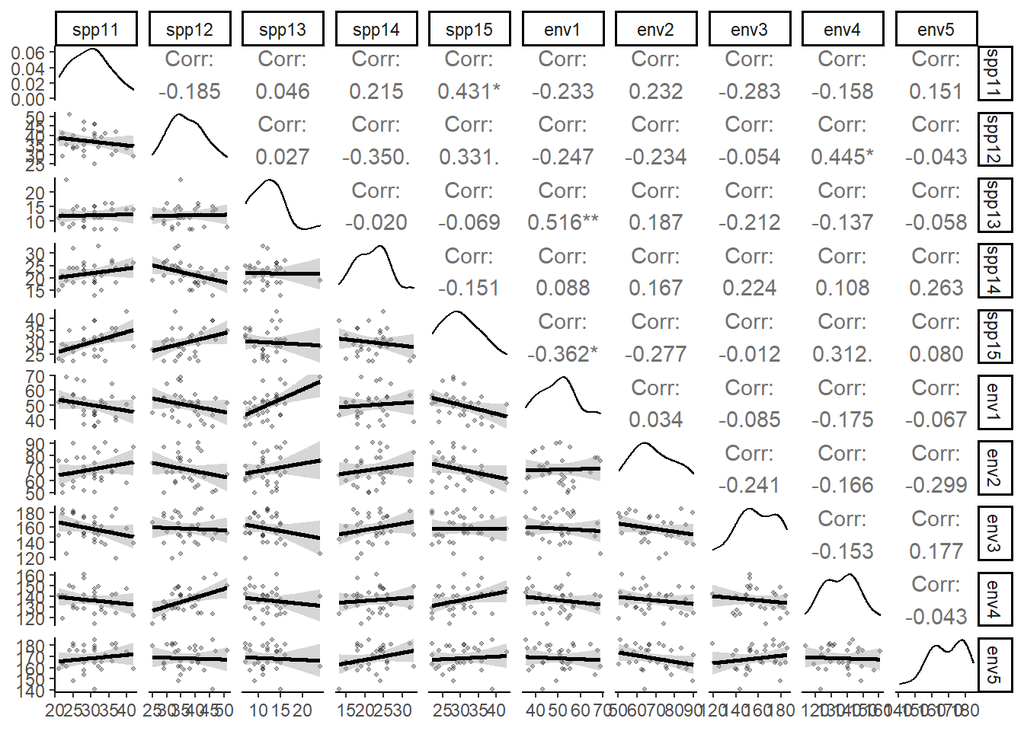

```r
do_sp11_sp15_env = ggpairs(data, columns = c(11:15,21:25), lower = list(continuous = wrap("smooth", alpha = 0.3, size = 0.7)))+
  theme_classic()
do_sp11_sp15_env
```

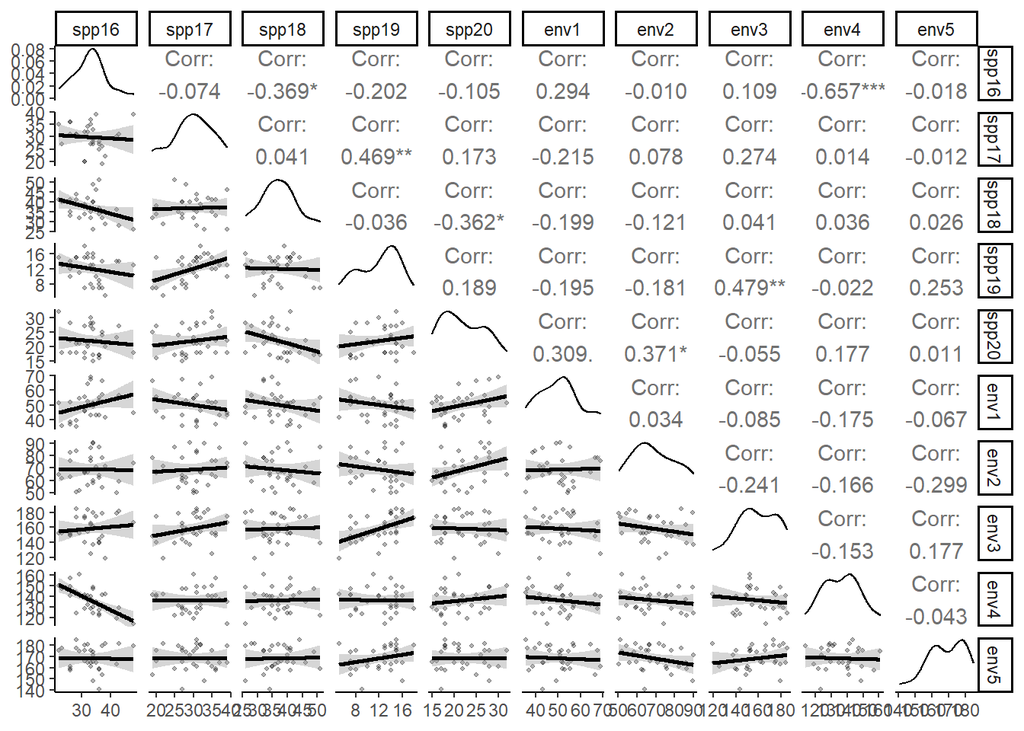

```r
do_sp16_sp20_env = ggpairs(data, columns = c(16:20,21:25), lower = list(continuous = wrap("smooth", alpha = 0.3, size = 0.7)))+
  theme_classic()
do_sp16_sp20_env
```

There are several significant linear relationships between species abundances and environmental variables. A linerar model to predict abundances from environental parameters may therefore be useful. Species abundances are often normally distributed but some are skewed, mostly to the right.

## 1.5 Correlation plot heatmap

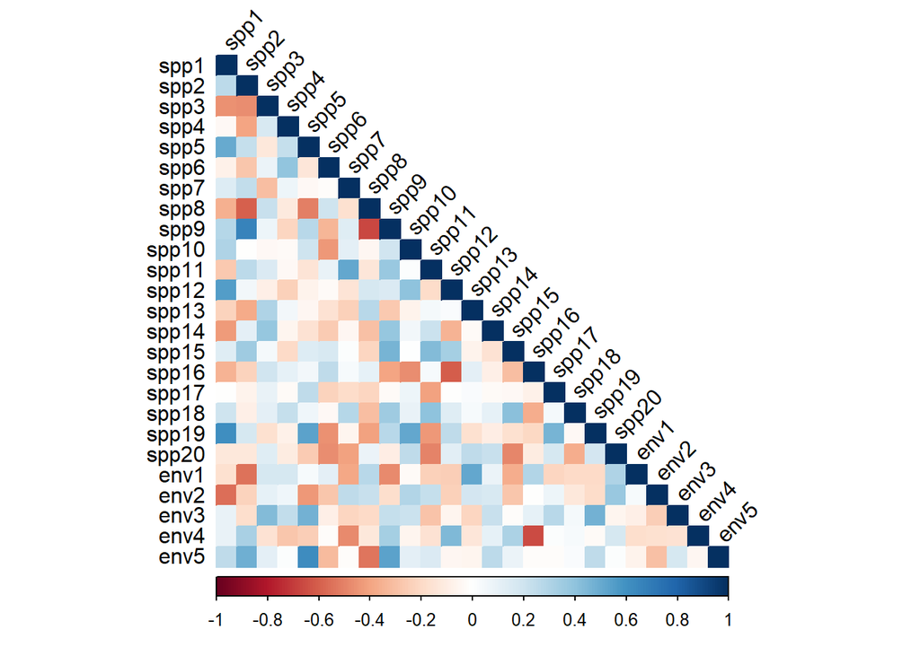

```r
corrplot(cor(data), method = "color", type = "lower",  tl.col = "black", tl.srt = 45)
```

In this heatmap all correlations between species abundances and environmental parameters can be seen at one glance. Correlations of varying degree are present between species abundances and environmental variables

## 1.6 Distribution of species 16 (relevant species for linear models)

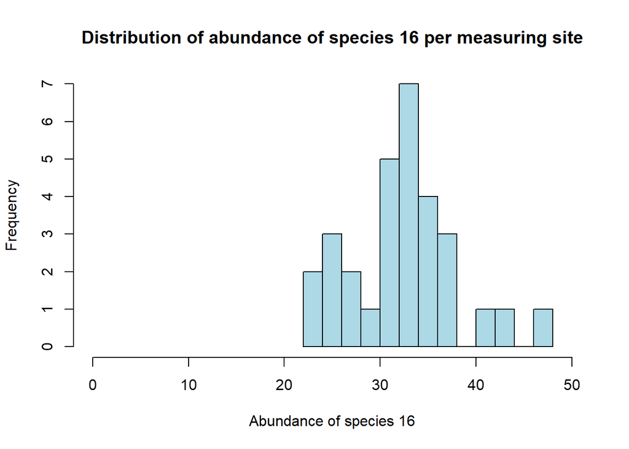

```r
hist(data$spp16, breaks = 15, xlim = c(0,50), xlab = "Abundance of species 16", main = "Distribution of abundance of species 16 per measuring site", col = "lightblue")
```

Approximately normally distributed

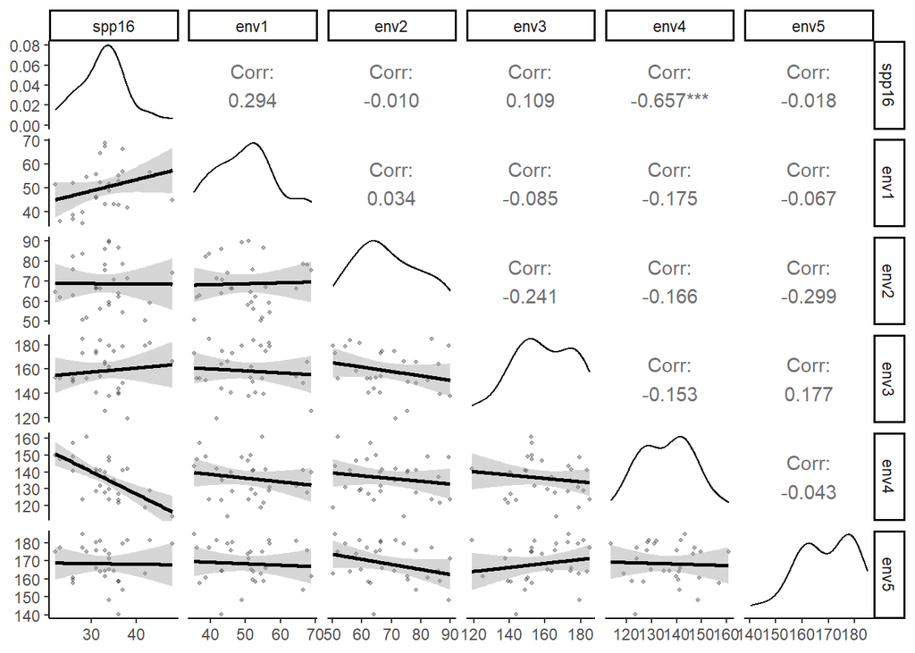

```r
do_sp16_env = ggpairs(data, columns = c(16,21:25), lower = list(continuous = wrap("smooth", alpha = 0.3, size = 0.7)))+
  theme_classic()
do_sp16_env
```

There are correlations between abundance of species 16 and the environmental parameters, the correlation between spp16 and env4 being significant

# 2 Linear models using stepwise model selection

## 2.1 Intercept and full model

To apply stepwise model selection, the intercept model (model without any environmental predictor) and the full model (model with all environmental parameters as predictors) must be specified

```r
intercept_model = lm(spp16 ~ 1, data = data)


full_model = lm(spp16 ~ env1 + env2 + env3 + env4 + env5, data = data)
```

## 2.2 Not including interaction terms

### 2.2.1 Forward stepwise model selection (no interaction)

```r
for_lm = step(intercept_model, scope=formula(full_model), directions = "forward")
```

```
## Start:  AIC=105.53
## spp16 ~ 1
##
##        Df Sum of Sq    RSS     AIC
## + env4  1    408.56 537.31  90.561
## + env1  1     82.02 863.84 104.806
## <none>              945.87 105.527
## + env3  1     11.16 934.71 107.171
## + env5  1      0.31 945.56 107.517
## + env2  1      0.09 945.78 107.524
##
## Step:  AIC=90.56
## spp16 ~ env4
##
##        Df Sum of Sq    RSS     AIC
## <none>              537.31  90.561
## + env1  1     31.38 505.93  90.756
## + env2  1     13.81 523.50  91.780
## + env5  1      2.04 535.27  92.447
## + env3  1      0.06 537.25  92.558
## - env4  1    408.56 945.87 105.527
```

```r
for_lm$coefficients
```

```
## (Intercept)        env4
##  77.5518043  -0.3271165
```

Resulting model:

$$spp16 = -0.327*env4 + 77$$

### 2.2.2 Backward stepwise model selection (no interaction)

```r
back_lm = step(full_model, scope=formula(full_model), directions = "backward")
```

```
## Start:  AIC=95.59
## spp16 ~ env1 + env2 + env3 + env4 + env5
##
##        Df Sum of Sq    RSS     AIC
## - env3  1      0.01 486.67  93.592
## - env5  1      5.21 491.88  93.911
## - env2  1     17.07 503.74  94.626
## - env1  1     29.17 515.84  95.338
## <none>              486.67  95.591
## - env4  1    359.63 846.30 110.190
##
## Step:  AIC=93.59
## spp16 ~ env1 + env2 + env4 + env5
##
##        Df Sum of Sq    RSS     AIC
## - env5  1      5.22 491.90  91.912
## - env2  1     18.24 504.91  92.696
## - env1  1     29.45 516.13  93.355
## <none>              486.67  93.592
## + env3  1      0.01 486.67  95.591
## - env4  1    376.78 863.45 108.792
##
## Step:  AIC=91.91
## spp16 ~ env1 + env2 + env4
##
##        Df Sum of Sq    RSS     AIC
## - env2  1     14.03 505.93  90.756
## - env1  1     31.61 523.50  91.780
## <none>              491.90  91.912
## + env5  1      5.22 486.67  93.592
## + env3  1      0.02 491.88  93.911
## - env4  1    371.57 863.47 106.793
##
## Step:  AIC=90.76
## spp16 ~ env1 + env4
##
##        Df Sum of Sq    RSS     AIC
## - env1  1     31.38 537.31  90.561
## <none>              505.93  90.756
## + env2  1     14.03 491.90  91.912
## + env5  1      1.01 504.91  92.696
## + env3  1      0.82 505.11  92.707
## - env4  1    357.91 863.84 104.806
##
## Step:  AIC=90.56
## spp16 ~ env4
##
##        Df Sum of Sq    RSS     AIC
## <none>              537.31  90.561
## + env1  1     31.38 505.93  90.756
## + env2  1     13.81 523.50  91.780
## + env5  1      2.04 535.27  92.447
## + env3  1      0.06 537.25  92.558
## - env4  1    408.56 945.87 105.527
```

```r
back_lm$coefficients
```

```
## (Intercept)        env4
##  77.5518043  -0.3271165
```

Resulting model:

$$spp16 = -0.327*env4 + 77$$

### 2.2.3 Both ways stepwise model selection (no interaction)

```r
both_lm = step(intercept_model, scope=formula(full_model), directions = "both")
```

```
## Start:  AIC=105.53
## spp16 ~ 1
##
##        Df Sum of Sq    RSS     AIC
## + env4  1    408.56 537.31  90.561
## + env1  1     82.02 863.84 104.806
## <none>              945.87 105.527
## + env3  1     11.16 934.71 107.171
## + env5  1      0.31 945.56 107.517
## + env2  1      0.09 945.78 107.524
##
## Step:  AIC=90.56
## spp16 ~ env4
##
##        Df Sum of Sq    RSS     AIC
## <none>              537.31  90.561
## + env1  1     31.38 505.93  90.756
## + env2  1     13.81 523.50  91.780
## + env5  1      2.04 535.27  92.447
## + env3  1      0.06 537.25  92.558
## - env4  1    408.56 945.87 105.527
```

```r
both_lm$coefficients
```

```
## (Intercept)        env4
##  77.5518043  -0.3271165
```

Resulting model:

$$spp16 = -0.327*env4 + 77$$

**All stepwise model selection methods without interactions resulted in the same model** **using only the predictor env4 to predict abundance of species 16**

### 2.2.4 Model diagnosis

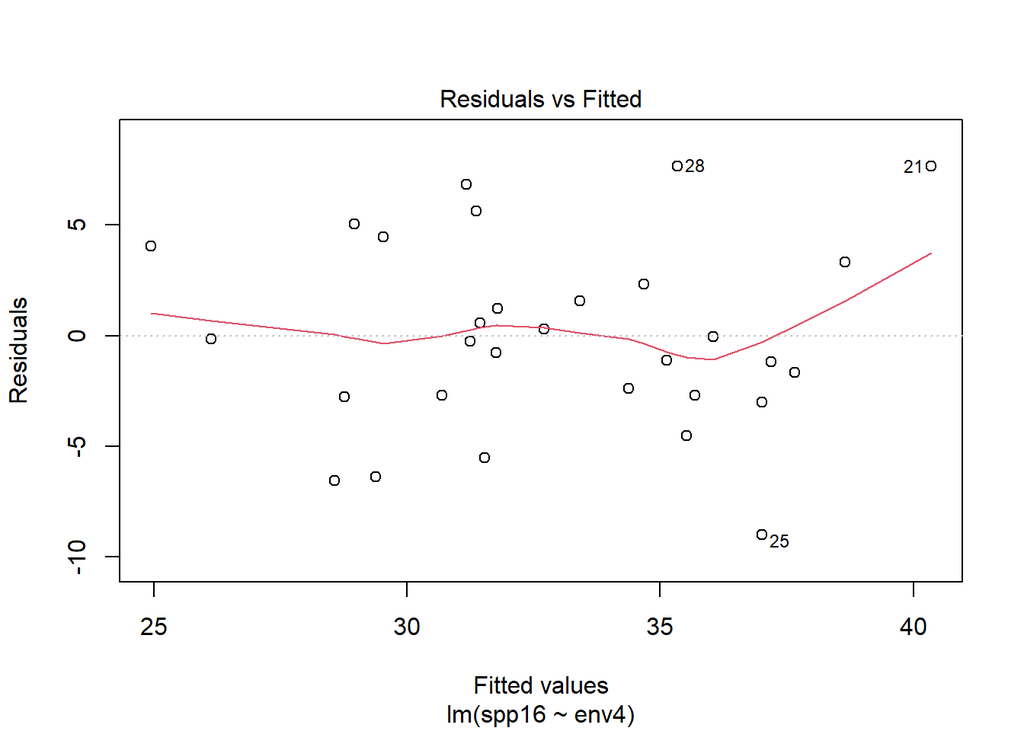

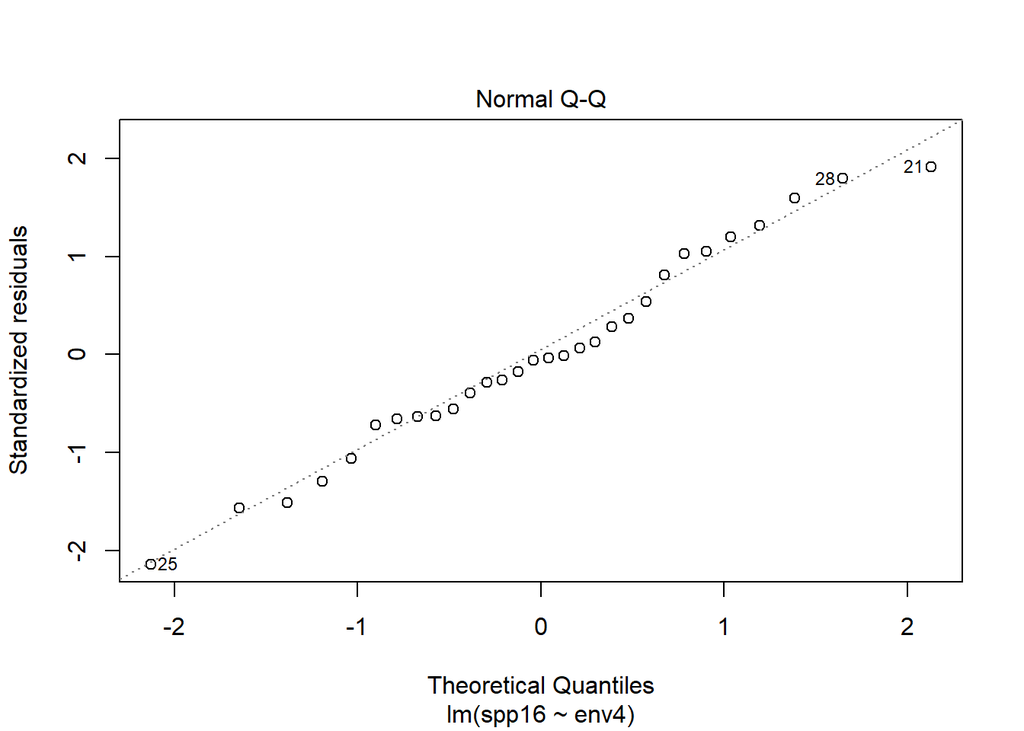

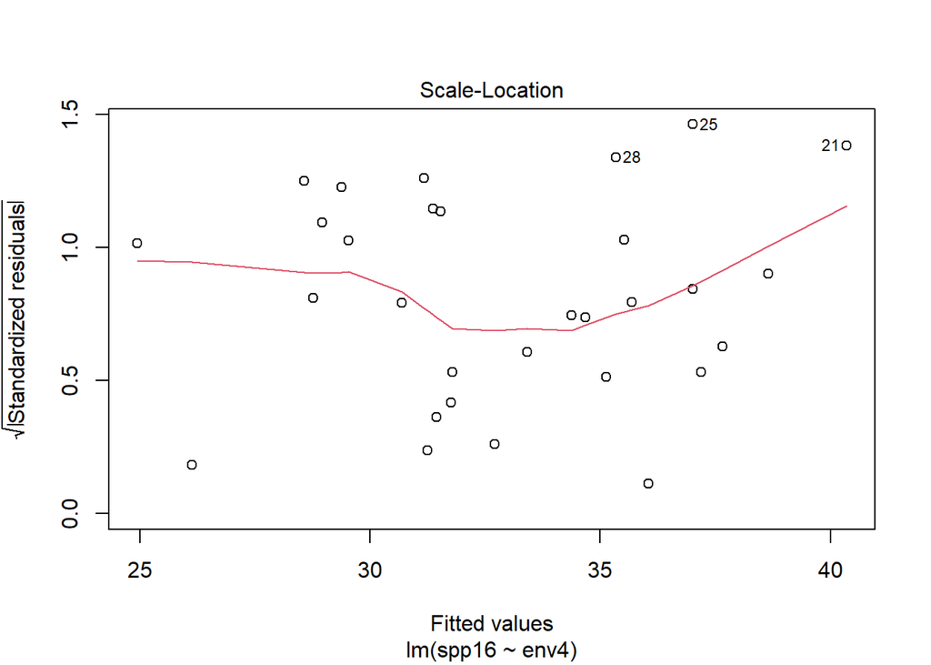

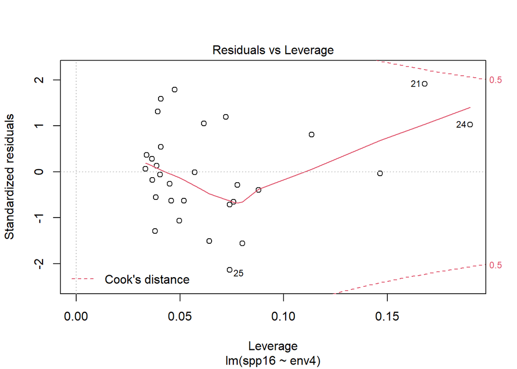

```r
plot(for_lm)
```

**Assumptions are fulfilled:**

- residuals are homogeneous (Homoscedasticity)
- Normal distribution of error
- There are no infuential outliers
- Observations should be independent, but data source is unknown
- Linearity has been checked in line 96
- Multicollinearity has been excluded in line 54

```r
summary(for_lm)
```

```
##
## Call:
## lm(formula = spp16 ~ env4, data = data)
##
## Residuals:
##     Min      1Q  Median      3Q     Max
## -9.0124 -2.6842 -0.1869  3.0879  7.6611
##
## Coefficients:
##             Estimate Std. Error t value Pr(>|t|)
## (Intercept) 77.55180    9.70291   7.993 1.05e-08 ***
## env4        -0.32712    0.07089  -4.614 7.96e-05 ***
## ---
## Signif. codes:  0 '***' 0.001 '**' 0.01 '*' 0.05 '.' 0.1 ' ' 1
##
## Residual standard error: 4.381 on 28 degrees of freedom
## Multiple R-squared:  0.4319, Adjusted R-squared:  0.4117
## F-statistic: 21.29 on 1 and 28 DF,  p-value: 7.96e-05
```

The relationship between env4 and spp16 is highly significant (p < 8*10^-5) But only about 43 % of variance are explained by the model.

## 2.3 Models with interaction terms

This time the full model includes interactions

```r
intercept_model = lm(spp16 ~ 1, data = data)


full_model_int = lm(spp16 ~ env1 * env2 * env3 * env4 * env5, data = data)
summary(full_model_int)
```

```
##
## Call:
## lm(formula = spp16 ~ env1 * env2 * env3 * env4 * env5, data = data)
##
## Residuals:
## ALL 30 residuals are 0: no residual degrees of freedom!
##
## Coefficients: (2 not defined because of singularities)
##                            Estimate Std. Error t value Pr(>|t|)
## (Intercept)               1.567e+05        NaN     NaN      NaN
## env1                     -3.331e+03        NaN     NaN      NaN
## env2                     -1.137e+03        NaN     NaN      NaN
## env3                     -9.596e+02        NaN     NaN      NaN
## env4                     -1.058e+03        NaN     NaN      NaN
## env5                     -5.959e+02        NaN     NaN      NaN
## env1:env2                 2.418e+01        NaN     NaN      NaN
## env1:env3                 2.058e+01        NaN     NaN      NaN
## env2:env3                 6.288e+00        NaN     NaN      NaN
## env1:env4                 2.173e+01        NaN     NaN      NaN
## env2:env4                 5.848e+00        NaN     NaN      NaN
## env3:env4                 6.587e+00        NaN     NaN      NaN
## env1:env5                 1.328e+01        NaN     NaN      NaN
## env2:env5                 2.879e+00        NaN     NaN      NaN
## env3:env5                 3.547e+00        NaN     NaN      NaN
## env4:env5                 3.761e+00        NaN     NaN      NaN
## env1:env2:env3           -1.398e-01        NaN     NaN      NaN
## env1:env2:env4           -1.137e-01        NaN     NaN      NaN
## env1:env3:env4           -1.363e-01        NaN     NaN      NaN
## env2:env3:env4           -3.209e-02        NaN     NaN      NaN
## env1:env2:env5           -6.531e-02        NaN     NaN      NaN
## env1:env3:env5           -8.030e-02        NaN     NaN      NaN
## env2:env3:env5           -1.230e-02        NaN     NaN      NaN
## env1:env4:env5           -7.964e-02        NaN     NaN      NaN
## env2:env4:env5           -5.204e-03        NaN     NaN      NaN
## env3:env4:env5           -2.292e-02        NaN     NaN      NaN
## env1:env2:env3:env4       6.544e-04        NaN     NaN      NaN
## env1:env2:env3:env5       3.230e-04        NaN     NaN      NaN
## env1:env2:env4:env5       7.324e-05        NaN     NaN      NaN
## env1:env3:env4:env5       4.916e-04        NaN     NaN      NaN
## env2:env3:env4:env5              NA         NA      NA       NA
## env1:env2:env3:env4:env5         NA         NA      NA       NA
##
## Residual standard error: NaN on 0 degrees of freedom
## Multiple R-squared:      1,  Adjusted R-squared:    NaN
## F-statistic:   NaN on 29 and 0 DF,  p-value: NA
```

With all interactions included in the full model, there are more predictors than observations. This is impossible to calculate. To demonstrate the inclusion of interaction terms nevertheless, the parameter env5 is simply removed from the model.

```r
full_model_int = lm(spp16 ~ env1 * env2 * env3 * env4, data = data)
summary(full_model_int)
```

```
##
## Call:
## lm(formula = spp16 ~ env1 * env2 * env3 * env4, data = data)
##
## Residuals:
##     Min      1Q  Median      3Q     Max
## -8.0993 -1.7816  0.6329  2.4775  6.6062
##
## Coefficients:
##                       Estimate Std. Error t value Pr(>|t|)
## (Intercept)         -5.377e+03  8.304e+03  -0.648    0.528
## env1                 9.098e+01  1.593e+02   0.571    0.577
## env2                 8.671e+01  1.129e+02   0.768    0.455
## env3                 3.342e+01  5.282e+01   0.633    0.537
## env4                 3.867e+01  5.960e+01   0.649    0.527
## env1:env2           -1.504e+00  2.187e+00  -0.688    0.503
## env1:env3           -5.516e-01  1.011e+00  -0.545    0.594
## env2:env3           -5.211e-01  7.089e-01  -0.735    0.474
## env1:env4           -6.504e-01  1.146e+00  -0.567    0.579
## env2:env4           -6.152e-01  8.130e-01  -0.757    0.462
## env3:env4           -2.390e-01  3.802e-01  -0.629    0.540
## env1:env2:env3       8.929e-03  1.374e-02   0.650    0.526
## env1:env2:env4       1.067e-02  1.579e-02   0.676    0.510
## env1:env3:env4       3.945e-03  7.305e-03   0.540    0.598
## env2:env3:env4       3.694e-03  5.129e-03   0.720    0.483
## env1:env2:env3:env4 -6.324e-05  9.975e-05  -0.634    0.536
##
## Residual standard error: 5.066 on 14 degrees of freedom
## Multiple R-squared:  0.6201, Adjusted R-squared:  0.2131
## F-statistic: 1.523 on 15 and 14 DF,  p-value: 0.2187
```

Now stepwise model selection can be done:

### 2.3.1 Forward stepwise model selection (with interaction)

```r
for_lm_int = step(intercept_model, scope=formula(full_model_int), directions = "forward")
```

```
## Start:  AIC=105.53
## spp16 ~ 1
##
##        Df Sum of Sq    RSS     AIC
## + env4  1    408.56 537.31  90.561
## + env1  1     82.02 863.84 104.806
## <none>              945.87 105.527
## + env3  1     11.16 934.71 107.171
## + env2  1      0.09 945.78 107.524
##
## Step:  AIC=90.56
## spp16 ~ env4
##
##        Df Sum of Sq    RSS     AIC
## <none>              537.31  90.561
## + env1  1     31.38 505.93  90.756
## + env2  1     13.81 523.50  91.780
## + env3  1      0.06 537.25  92.558
## - env4  1    408.56 945.87 105.527
```

```r
for_lm_int$coefficients
```

```
## (Intercept)        env4
##  77.5518043  -0.3271165
```

Resulting model:

$$spp16 = -0.327*env4 + 77.552$$
(only env4 as predictor)

### 2.3.2 Backward stepwise model selection (with interaction)

```r
back_lm_int = step(full_model_int, scope=formula(full_model_int), directions = "backward")
```

```
## Start:  AIC=106.49
## spp16 ~ env1 * env2 * env3 * env4
##
##                       Df Sum of Sq    RSS    AIC
## - env1:env2:env3:env4  1    10.318 369.65 105.34
## <none>                             359.33 106.49
##
## Step:  AIC=105.34
## spp16 ~ env1 + env2 + env3 + env4 + env1:env2 + env1:env3 + env2:env3 +
##     env1:env4 + env2:env4 + env3:env4 + env1:env2:env3 + env1:env2:env4 +
##     env1:env3:env4 + env2:env3:env4
##
##                       Df Sum of Sq    RSS    AIC
## - env1:env2:env3       1    1.3739 371.02 103.45
## - env1:env3:env4       1    3.3024 372.95 103.61
## - env1:env2:env4       1    4.3171 373.97 103.69
## - env2:env3:env4       1   20.1683 389.82 104.94
## <none>                             369.65 105.34
## + env1:env2:env3:env4  1   10.3179 359.33 106.49
##
## Step:  AIC=103.45
## spp16 ~ env1 + env2 + env3 + env4 + env1:env2 + env1:env3 + env2:env3 +
##     env1:env4 + env2:env4 + env3:env4 + env1:env2:env4 + env1:env3:env4 +
##     env2:env3:env4
##
##                  Df Sum of Sq    RSS    AIC
## - env1:env2:env4  1    3.0766 374.10 101.70
## - env1:env3:env4  1    4.0751 375.10 101.78
## - env2:env3:env4  1   18.8203 389.84 102.94
## <none>                        371.02 103.45
## + env1:env2:env3  1    1.3739 369.65 105.34
##
## Step:  AIC=101.7
## spp16 ~ env1 + env2 + env3 + env4 + env1:env2 + env1:env3 + env2:env3 +
##     env1:env4 + env2:env4 + env3:env4 + env1:env3:env4 + env2:env3:env4
##
##                  Df Sum of Sq    RSS     AIC
## - env1:env3:env4  1    2.0570 376.16  99.864
## - env1:env2       1    2.5974 376.70  99.907
## - env2:env3:env4  1   22.2519 396.35 101.433
```

[output cut: 25 more lines]

```
## - env2:env3:env4  1    26.673 409.34 98.401
## - env1:env4       1    43.877 426.55 99.636
## + env1:env2       1     6.513 376.16 99.864
## + env1:env3:env4  1     5.973 376.70 99.907
##
## Step:  AIC=98.28
## spp16 ~ env1 + env2 + env3 + env4 + env2:env3 + env1:env4 + env2:env4 +
##     env3:env4 + env2:env3:env4
##
##                  Df Sum of Sq    RSS     AIC
## <none>                        407.68  98.278
## - env1:env4       1    29.212 436.89  98.354
## + env1:env3       1    25.005 382.67  98.379
## - env2:env3:env4  1    42.726 450.40  99.268
## + env1:env2       1     0.100 407.58 100.271
```

```r
back_lm_int$coefficients
```

```
##    (Intercept)           env1           env2           env3           env4
##  -7.111695e+02  -1.752067e+00   1.171147e+01   5.885011e+00   5.416511e+00
##      env2:env3      env1:env4      env2:env4      env3:env4 env2:env3:env4
##  -7.958172e-02   1.322625e-02  -8.532077e-02  -4.284614e-02   5.774564e-04
```

Resulting model contains the predictors **env1, env2, env3, env4, env2:env3, env1:env4, env2:env4,** **env3:env4 and env2:env3:env4**

### 2.3.3 Both ways stepwise model selection (with interaction)

```r
both_lm_int = step(intercept_model, scope=formula(full_model_int), directions = "both")
```

```
## Start:  AIC=105.53
## spp16 ~ 1
##
##        Df Sum of Sq    RSS     AIC
## + env4  1    408.56 537.31  90.561
## + env1  1     82.02 863.84 104.806
## <none>              945.87 105.527
## + env3  1     11.16 934.71 107.171
## + env2  1      0.09 945.78 107.524
##
## Step:  AIC=90.56
## spp16 ~ env4
##
##        Df Sum of Sq    RSS     AIC
## <none>              537.31  90.561
## + env1  1     31.38 505.93  90.756
## + env2  1     13.81 523.50  91.780
## + env3  1      0.06 537.25  92.558
## - env4  1    408.56 945.87 105.527
```

```r
both_lm_int$coefficients
```

```
## (Intercept)        env4
##  77.5518043  -0.3271165
```

Resulting model:

$$spp16 = -0.327*env4 + 77.552$$
(only env4 as predictor), same model as forward stepwise selection

Forward and both directions stepwise selection resulted in a sparce model containing only env4 as a predictor. Backward stepwise selection included env1, env2, env3, env4, env2:env3, env1:env4, env2:env4, env3:env4 and env2:env3:env4

### 2.3.4 Diagnosis and interpretation

#### 2.3.4.1 Forward and both directions stepwise model selection

Both resulted in the same model

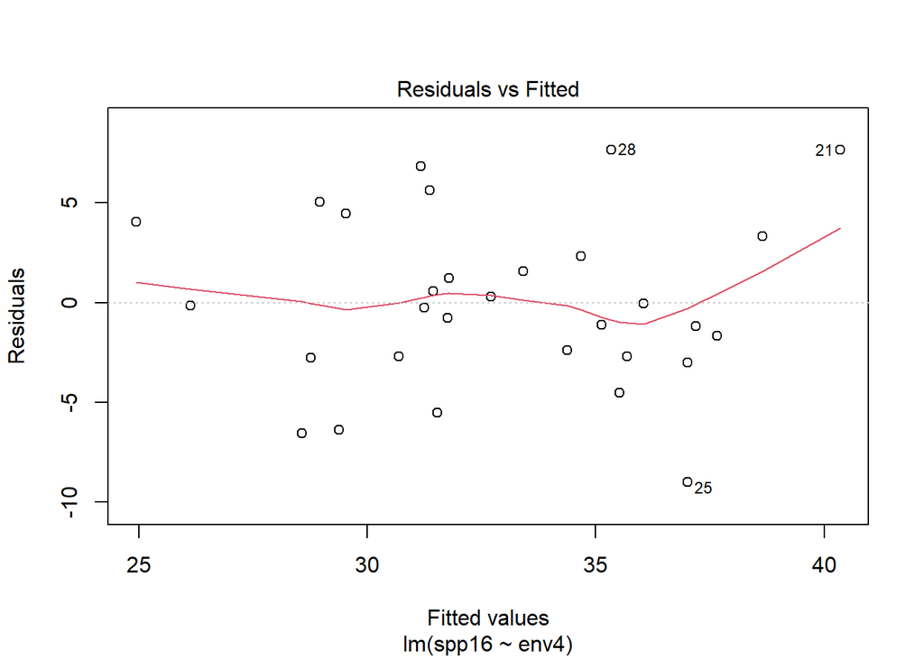

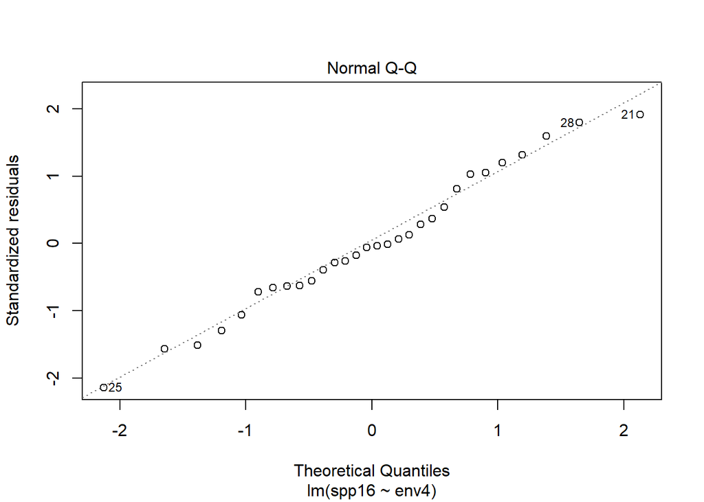

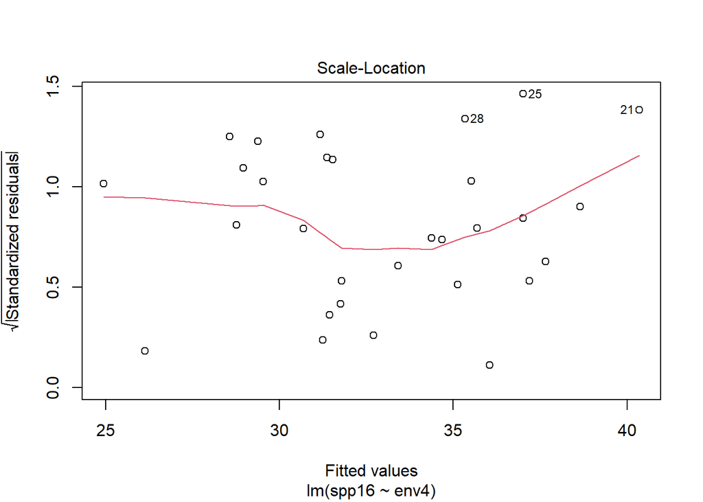

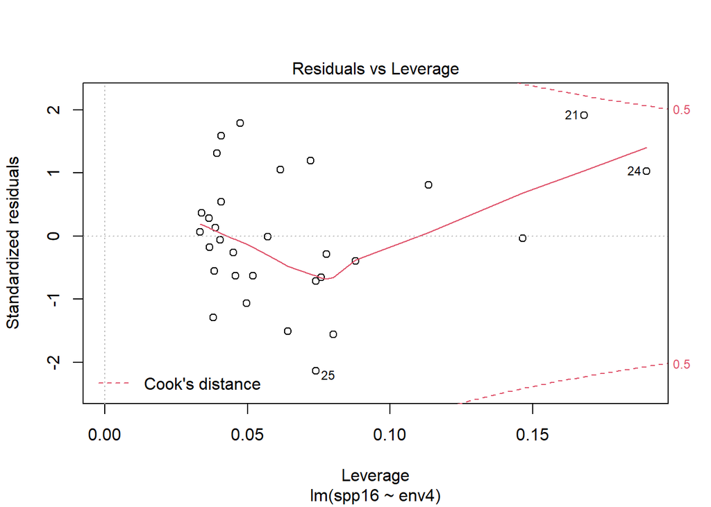

```r
plot(for_lm_int)
```

**Assumptions for forward and both direction stepwise selection models are fulfilled:**

- residuals are homogeneous (Homoscedasticity)
- Normal distribution of error
- There are no infuential outliers
- Observations should be independent, but data source is unknown
- Linearity has been checked in line 96
- Multicollinearity has been excluded in line 54

#### 2.3.4.2 Backward model selection

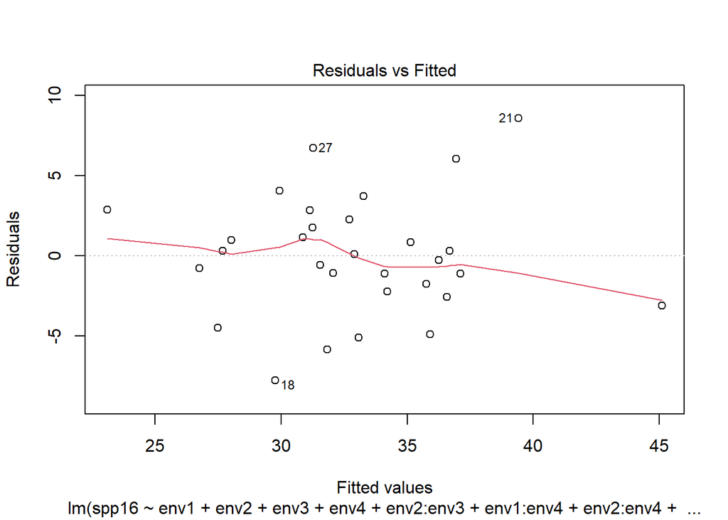

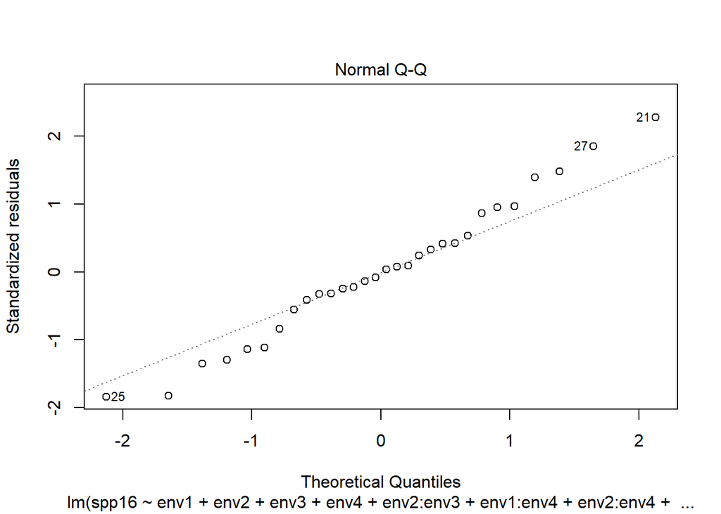

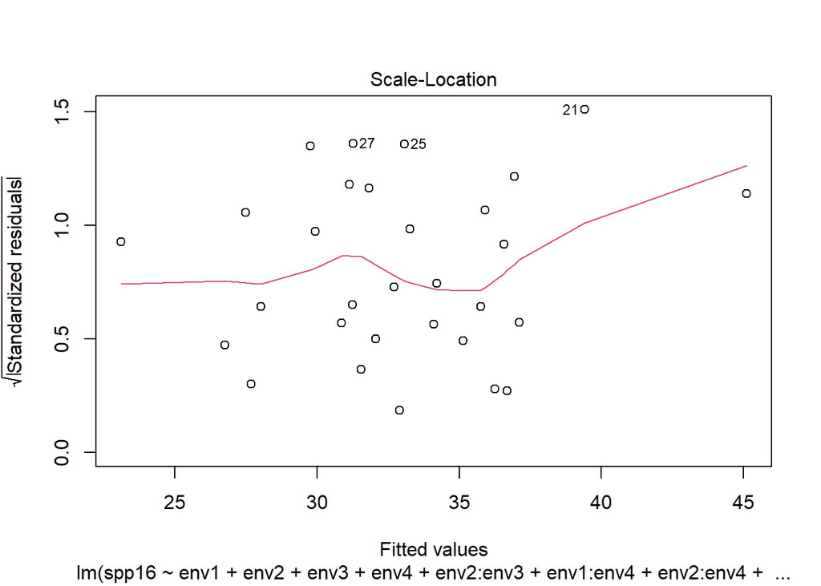

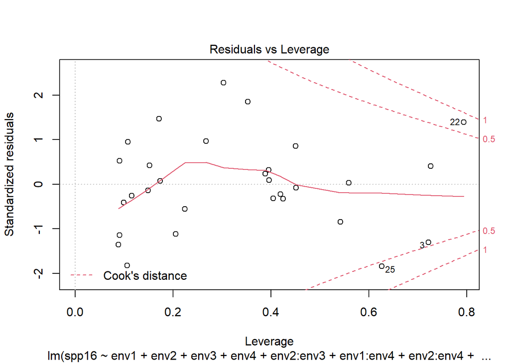

```r
plot(back_lm_int)
```

**Assumptions for backward stepwise selection model are not completely fulfilled:**

- residuals are only more or less homogeneous (Homoscedasticity)
- Error is normally distributed although not as clearly as the previous models
- There are at least two infuential outliers
- Observations should be independent, but data source is unknown
- Linearity has been checked in data exploration
- Multicollinearity is present due to interaction terms (see below)

Checking for multilinearity in the linear model with interaction terms:

```r
vif(lm(spp1 ~ env1 * env2 * env3 * env4, data = data))
```

```
## there are higher-order terms (interactions) in this model
## consider setting type = 'predictor'; see ?vif
```

```
##                env1                env2                env3                env4
##           2414468.6           1985330.4            971590.6            528346.6
##           env1:env2           env1:env3           env2:env3           env1:env4
##           4285954.8           3014143.0           2340873.2           2488870.1
##           env2:env4           env3:env4      env1:env2:env3      env1:env2:env4
##           2043487.4           1240904.5           3938271.3           4015793.2
##      env1:env3:env4      env2:env3:env4 env1:env2:env3:env4
##           2874011.8           2336964.1           3700600.1
```

Very high VIFs -> multicollinearity

```r
vif(lm(spp1 ~ env1 + env2 + env3 + env4, data = data)) # Low VIFs in the model without interactions
```

```
##     env1     env2     env3     env4
## 1.046337 1.112306 1.122250 1.113370
```

Low VIFs in the model without interactions

```r
vif(lm(spp1 ~ env1:env2 + env2:env3 + env1:env4 + env2:env4 + env3:env4 + env1:env2:env3 +env1:env2:env4 + env1:env3:env4 + env2:env3:env4 + env1:env2:env3:env4, data = data))
```

```
## there are higher-order terms (interactions) in this model
## consider setting type = 'predictor'; see ?vif
```

```
##           env1:env2           env2:env3           env1:env4           env2:env4
##          1516.83640           425.61586           325.79042           236.61798
##           env3:env4      env1:env2:env3      env1:env2:env4      env1:env3:env4
##            82.61053          1922.25379          2435.73868           366.68445
##      env2:env3:env4 env1:env2:env3:env4
##          1314.85392          2790.05928
```

High VIFs in model with only interactions

#### 2.3.4.3 Interpretation forward and both directions model

```r
summary(for_lm_int)
```

```
##
## Call:
## lm(formula = spp16 ~ env4, data = data)
##
## Residuals:
##     Min      1Q  Median      3Q     Max
## -9.0124 -2.6842 -0.1869  3.0879  7.6611
##
## Coefficients:
##             Estimate Std. Error t value Pr(>|t|)
## (Intercept) 77.55180    9.70291   7.993 1.05e-08 ***
## env4        -0.32712    0.07089  -4.614 7.96e-05 ***
## ---
## Signif. codes:  0 '***' 0.001 '**' 0.01 '*' 0.05 '.' 0.1 ' ' 1
##
## Residual standard error: 4.381 on 28 degrees of freedom
## Multiple R-squared:  0.4319, Adjusted R-squared:  0.4117
## F-statistic: 21.29 on 1 and 28 DF,  p-value: 7.96e-05
```

The relationship between env4 and spp16 is highly significant (p < 8*10^-5) But only about 43 % of variance are explained by the model (or 41 % when considering adjusted R^2)

#### 2.3.4.4 Interpretation backward stepwise selection model

```r
summary(back_lm_int)
```

```
##
## Call:
## lm(formula = spp16 ~ env1 + env2 + env3 + env4 + env2:env3 +
##     env1:env4 + env2:env4 + env3:env4 + env2:env3:env4, data = data)
##
## Residuals:
##     Min      1Q  Median      3Q     Max
## -7.7819 -2.0996 -0.0797  2.1492  8.5884
##
## Coefficients:
##                  Estimate Std. Error t value Pr(>|t|)
## (Intercept)    -7.112e+02  6.184e+02  -1.150    0.264
## env1           -1.752e+00  1.541e+00  -1.137    0.269
## env2            1.171e+01  8.521e+00   1.374    0.185
## env3            5.885e+00  3.892e+00   1.512    0.146
## env4            5.417e+00  4.650e+00   1.165    0.258
## env2:env3      -7.958e-02  5.312e-02  -1.498    0.150
## env1:env4       1.323e-02  1.105e-02   1.197    0.245
## env2:env4      -8.532e-02  6.407e-02  -1.332    0.198
## env3:env4      -4.285e-02  2.915e-02  -1.470    0.157
## env2:env3:env4  5.775e-04  3.989e-04   1.448    0.163
##
## Residual standard error: 4.515 on 20 degrees of freedom
## Multiple R-squared:  0.569,  Adjusted R-squared:  0.375
## F-statistic: 2.934 on 9 and 20 DF,  p-value: 0.02157
```

There is a significant relationship between model predictors and abundance of species 16 (p = 0.022 < 0.05) R^2 is higher than the sparse model including only env4, however adjusted R^2 is lower due to the number of predictors. The relationship is also less significant. Overall the sparse model including only env4 (and no interactions) would be preferred as it explains a considerable degree of variance using only one predictor and very low p-value

# 3 Nonmetric multidimensional scaling (NMDS)

Calculating NMDS using “Bray-Curtis-dissimilarity” as a distance metric

```
## Square root transformation
## Wisconsin double standardization
## *** Solution reached
```

Plotting the NMDS graph

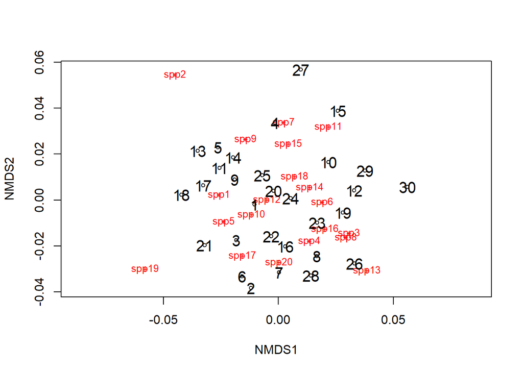

```r
plot(nmds)
orditorp(nmds,display="species",col="red",air=0.01, cex = 0.8) # indicating species points in graph
orditorp(nmds,display="sites",cex=1.25,air=0.01) # indicating site points in graph
```

**A multitude of information may be gathered from the NMDS graph. Some of the insights might be:**

- Site 27 and 2 are very different
- Sites 13, 5, 14, 11, 9 and 17 cluster together and seem to be rather similar
- Species 8 and species 3 seem to be the most similar species
- Species 2 and species 13 are the most different

# 4 Redundancy analysis (RDA)

## 4.1 Hellinger transformation

First to run the RDA, the abundance data must be transformed to fulfill the assumptions for multiple linear regression (normal distribution and constant variance) For that the “Hellinger transformation” is used

```r
sp.hellinger = decostand(sp, method = "hellinger")

sp.melt = melt(sp)
```

```
## Using  as id variables
```

```r
sp.h.melt = melt(sp.hellinger)
```

```
## Using  as id variables
```

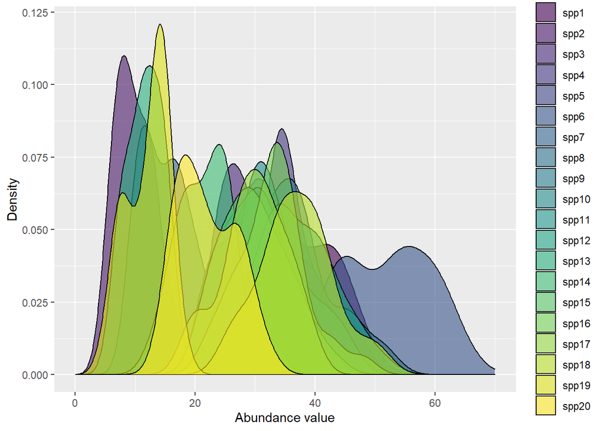

Distribution of untransformed abundances

```r
ggplot(sp.melt, aes(x=value, fill=variable)) +
  geom_density(alpha=0.6) + xlim(0,70) +
  scale_fill_viridis(discrete=TRUE) +
  scale_color_viridis(discrete=TRUE) +
  ylab("Density") +
  xlab("Abundance value")
```

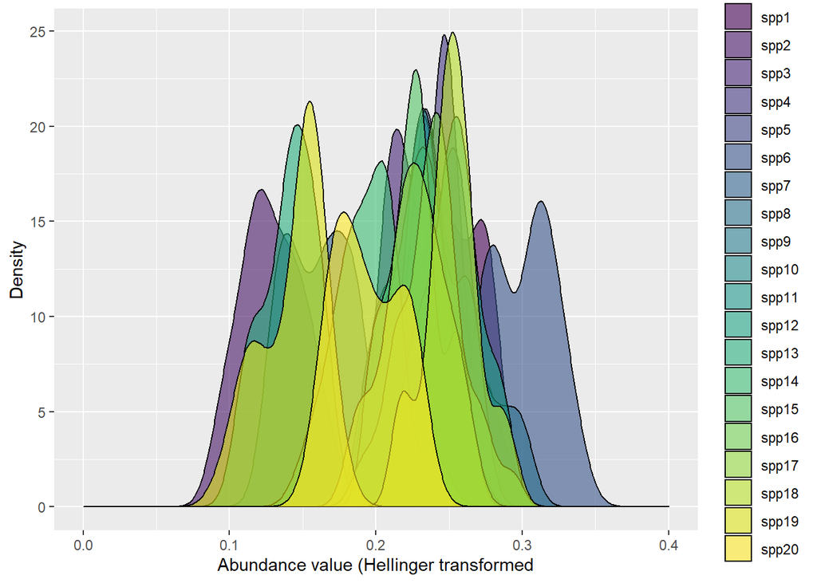

Distribution of Hellinger transformed abundances

```r
ggplot(sp.h.melt, aes(x=value, fill=variable)) +
  geom_density(alpha=0.6) + xlim(0,0.4) +
  scale_fill_viridis(discrete=TRUE) +
  scale_color_viridis(discrete=TRUE) +
  ylab("Density") +
  xlab("Abundance value (Hellinger transformed")
```

Hellinger transformation lead to more normally distributed abundances

## 4.2 Running RDA

```r
RDA <- rda(sp.hellinger ~ ., data = env)

summary(RDA, display = NA)
```

```
##
## Call:
## rda(formula = sp.hellinger ~ env1 + env2 + env3 + env4 + env5,      data = env)
##
## Partitioning of variance:
##                Inertia Proportion
## Total         0.008403     1.0000
## Constrained   0.002883     0.3431
## Unconstrained 0.005520     0.6569
##
## Eigenvalues, and their contribution to the variance
##
## Importance of components:
##                           RDA1      RDA2      RDA3      RDA4      RDA5      PC1
## Eigenvalue            0.001074 0.0006966 0.0004832 0.0004322 0.0001969 0.001351
## Proportion Explained  0.127829 0.0828999 0.0575056 0.0514303 0.0234368 0.160790
## Cumulative Proportion 0.127829 0.2107287 0.2682343 0.3196646 0.3431014 0.503891
##                             PC2       PC3       PC4      PC5       PC6
## Eigenvalue            0.0008525 0.0006979 0.0006335 0.000543 0.0004543
## Proportion Explained  0.1014531 0.0830497 0.0753844 0.064614 0.0540696
## Cumulative Proportion 0.6053445 0.6883941 0.7637785 0.828393 0.8824623
##                             PC7       PC8       PC9      PC10      PC11
## Eigenvalue            0.0002459 0.0001765 0.0001487 0.0001301 0.0001131
## Proportion Explained  0.0292684 0.0210041 0.0176911 0.0154834 0.0134556
## Cumulative Proportion 0.9117307 0.9327348 0.9504259 0.9659093 0.9793649
##                            PC12      PC13      PC14      PC15      PC16
## Eigenvalue            6.153e-05 4.202e-05 3.159e-05 1.587e-05 1.097e-05
## Proportion Explained  7.322e-03 5.001e-03 3.759e-03 1.888e-03 1.305e-03
## Cumulative Proportion 9.867e-01 9.917e-01 9.954e-01 9.973e-01 9.986e-01
##                            PC17      PC18      PC19      PC20
## Eigenvalue            7.350e-06 2.372e-06 1.397e-06 2.939e-07
## Proportion Explained  8.747e-04 2.823e-04 1.663e-04 3.497e-05
## Cumulative Proportion 9.995e-01 9.998e-01 1.000e+00 1.000e+00
##
## Accumulated constrained eigenvalues
## Importance of components:
##                           RDA1      RDA2      RDA3      RDA4      RDA5
## Eigenvalue            0.001074 0.0006966 0.0004832 0.0004322 0.0001969
## Proportion Explained  0.372569 0.2416192 0.1676051 0.1498983 0.0683086
## Cumulative Proportion 0.372569 0.6141880 0.7817931 0.9316914 1.0000000
##
## Scaling 2 for species and site scores
## * Species are scaled proportional to eigenvalues
## * Sites are unscaled: weighted dispersion equal on all dimensions
## * General scaling constant of scores:
```

Env 1-5 explain about 34% of variance in species composition across sites

### 4.2.1 Plotting RDA

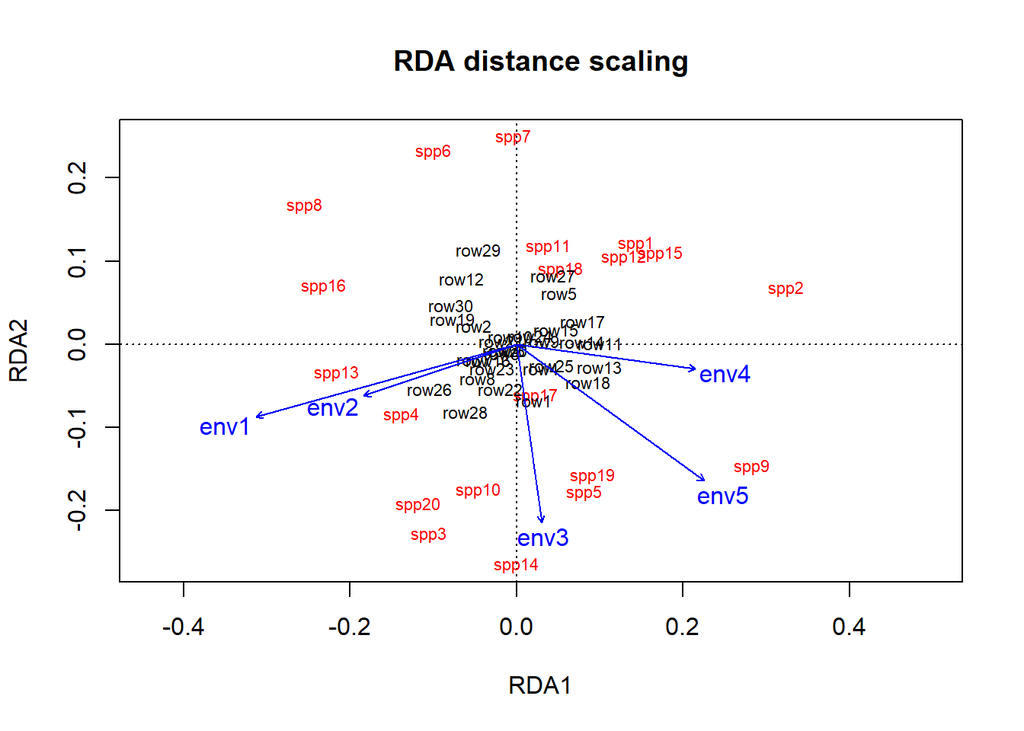

```r
ordiplot(RDA, scaling = 1, type = "text", main = "RDA distance scaling")
```

Insights:

- Species 1, 12 and 15 are very similar to each other
- Species 19 and 5 are very similar to each other
- Species 7 and 14 are very different
- Species 9 and 8 are very different
- env3 has a strong positive effect on abundance of species 14 and a negative effect on species 7 abundance
- Species 13 abundance is positively affected by env1 and env2
- Species 2, 1, 12 and 15 abundances have a negative relationship with env1 and env2
- The negative relationship between env4 and species 16 abundance can be seen in the RDA as well
- Similarity of species composition of rows (sites) can be assessed by their relative distance to each other aswell

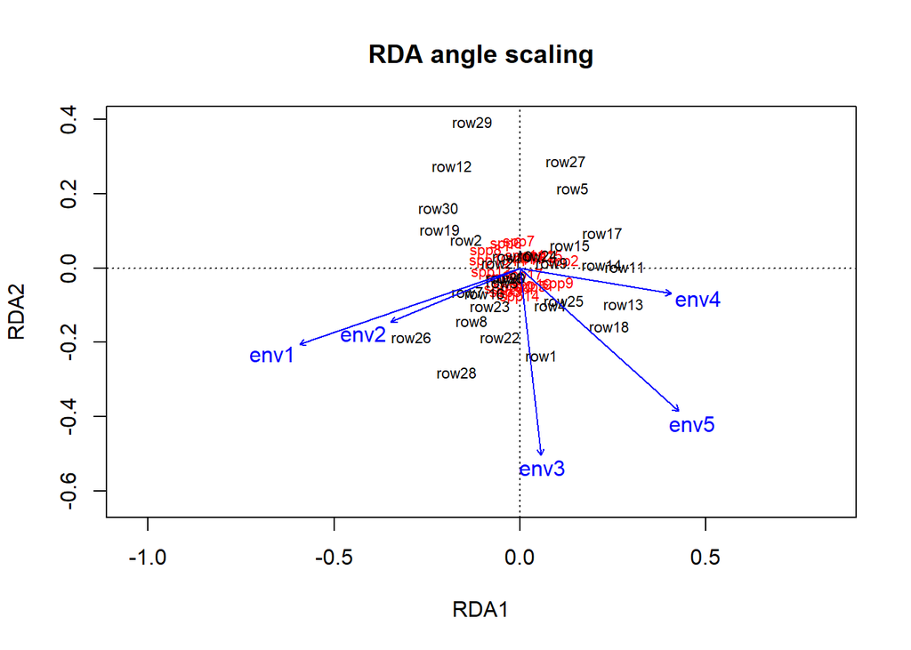

```r
ordiplot(RDA, scaling = 2, type = "text", main = "RDA angle scaling")
```